# Starting with smooth descent

Alejandro Therese Navarro

December 2021

Smooth Descent is a map-cleaning algorithm that can calculate identity by descent probabilities, predict genotyping errors and impute corrected genotypes. By applying this method, new genetic maps can be estimated to improve genetic map quality in an iterative process, similarly as was done in SMOOTH (van Os et al. 2006)[^1]

If you want to qucikly use `SmoothDescent` go to the Quick guide section, for the general user, the Introduction and Visualization sections should be enough to use the package. If you want to get into the nitty gritty, check out the Paramters and Basic functions sections.

# Quick guide

For a full explanation go to the following sections.

## Installation

To install, you can do it from the github page using `devtools`.

```r
devtools::install_github("https://github.com/Alethere/SmoothDescent")
#to install the vignette as well use (takes some time)
devtools::install_github("https://github.com/Alethere/SmoothDescent", build_vignettes = T)
```

## One smoothing round

If you already have a map and just want to obtain IBDs, error probabilities and updated genotypes, use `smooth_descent()`:

```r
sd1 <- smooth_descent(geno = geno, homologue = hom, map = map,
                      ploidy = 2, p1name = "P1", p2name = "P2")
```

```
## Obtaining IBD
## Predicting IBD
## Detecting errors
## Updating genotypes
## Counting recombinations
```

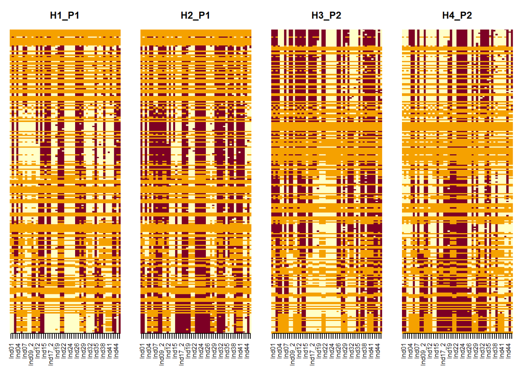

```r
#The observed IBD matrix
graphical_genotype(sd1$obsIBD)
```

```r
#The predicted IBD matrix
graphical_genotype(sd1$predIBD)
```

[output not shown]

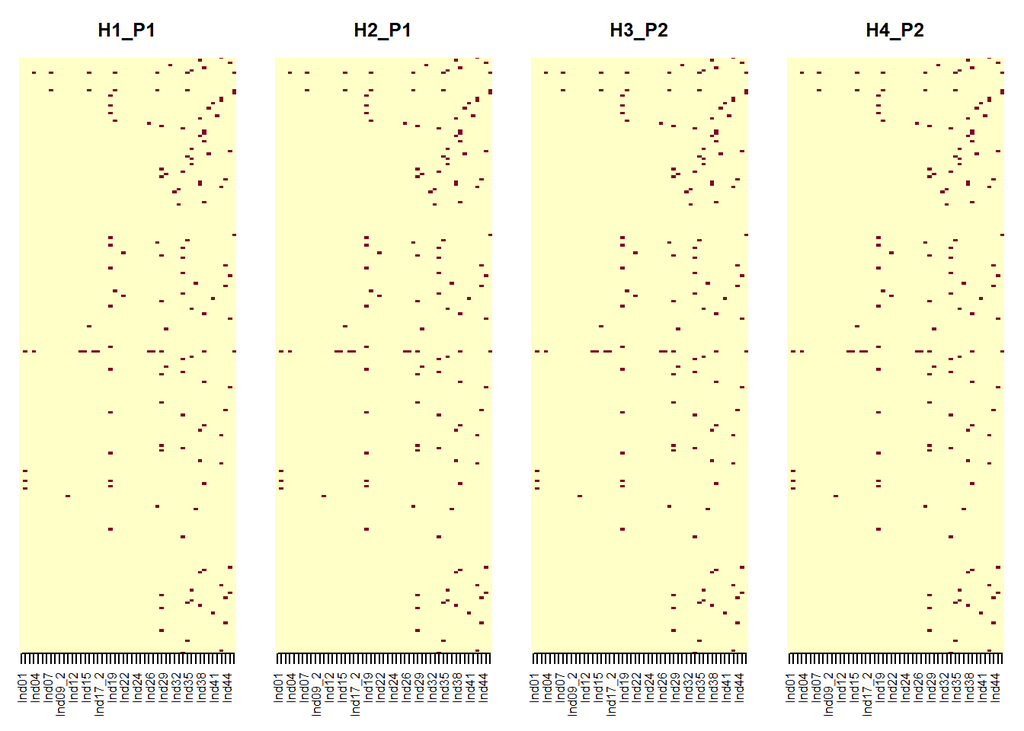

```r
#The error matrix
graphical_genotype(sd1$error)
```

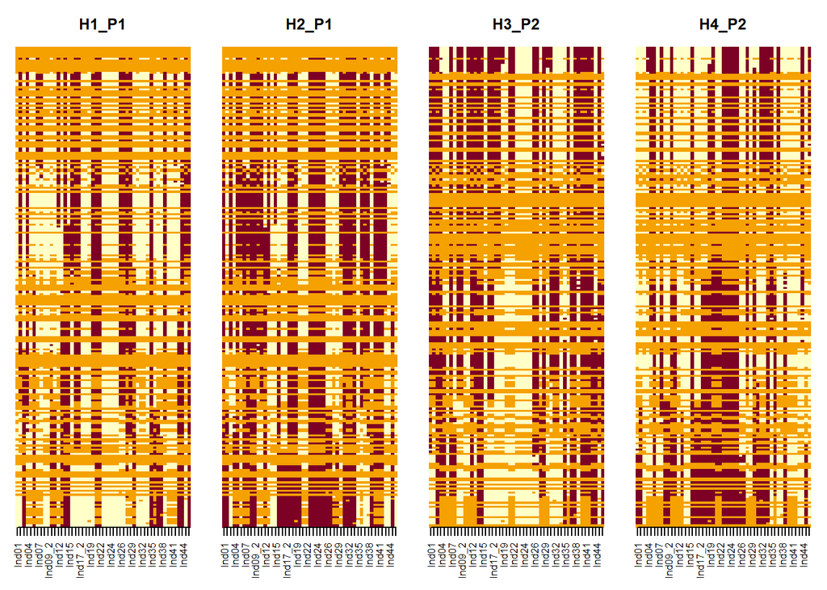

```r
#The new IBD matrix
graphical_genotype(sd1$newIBD)
```

```r
knitr::kable(sd1$newgeno[1:10,1:10])
```

|  | P1 | P2 | Ind01 | Ind02 | Ind03 | Ind04 | Ind05 | Ind06 | Ind07 | Ind08 |
| --- | --- | --- | --- | --- | --- | --- | --- | --- | --- | --- |
| m1 | 0 | 1 | 1 | 1 | 1 | 0 | 0 | 0 | 1 | 0 |
| m2 | 0 | 1 | 1 | 1 | 1 | 0 | 0 | 0 | 1 | 0 |
| m3 | 0 | 1 | 1 | 1 | 1 | 0 | 0 | 0 | 1 | 0 |
| m4 | 0 | 1 | 1 | 1 | 1 | 0 | 0 | 0 | 1 | 0 |
| m5 | 0 | 1 | 1 | 1 | 1 | 0 | 0 | 0 | 1 | 0 |
| m6 | 0 | 1 | 1 | 1 | 1 | 0 | 0 | 0 | 1 | 0 |
| m7 | 1 | 1 | 1 | 0 | 1 | 0 | 2 | 2 | 0 | 1 |
| m8 | 0 | 1 | 1 | 1 | 1 | 0 | 0 | 0 | 1 | 0 |
| m9 | 0 | 1 | 0 | 0 | 0 | 1 | 1 | 1 | 0 | 1 |
| m10 | 0 | 1 | 1 | 1 | 1 | 0 | 0 | 0 | 1 | 0 |

## One smoothing and mapping round

If you want to use improved genotypes to estimate a new order with a single round of mapping, you can use `smooth_map()`. You can provide a preliminary order or let the program estimate it automatically.

```r
#There's no preliminary map made in this example, so it's calculated at the beggining
#We do not evaluate this chunk to build the vignette faster
#Results equivalent to sd_iter$iter1
sm1 <- smooth_map(geno = geno, homologue = hom ,
                  ploidy = 2, p1name = "P1", p2name = "P2",
                  mapping_ndim = 3)
```

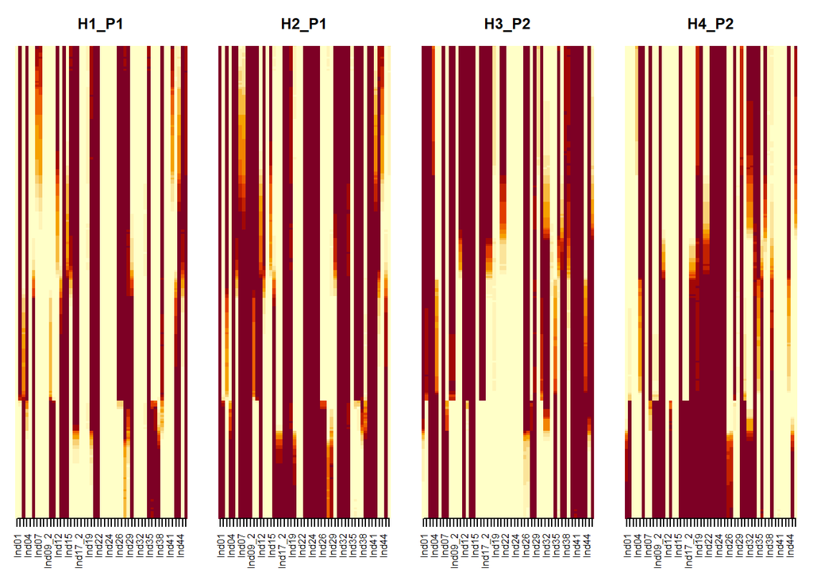

```r
#Using the stored object to build the vignette faster
sm1 <- sd_iter$iter1
#Same outputs as before, plus a newmap, recdist and r2 parameters
graphical_genotype(sm1$predIBD)
```

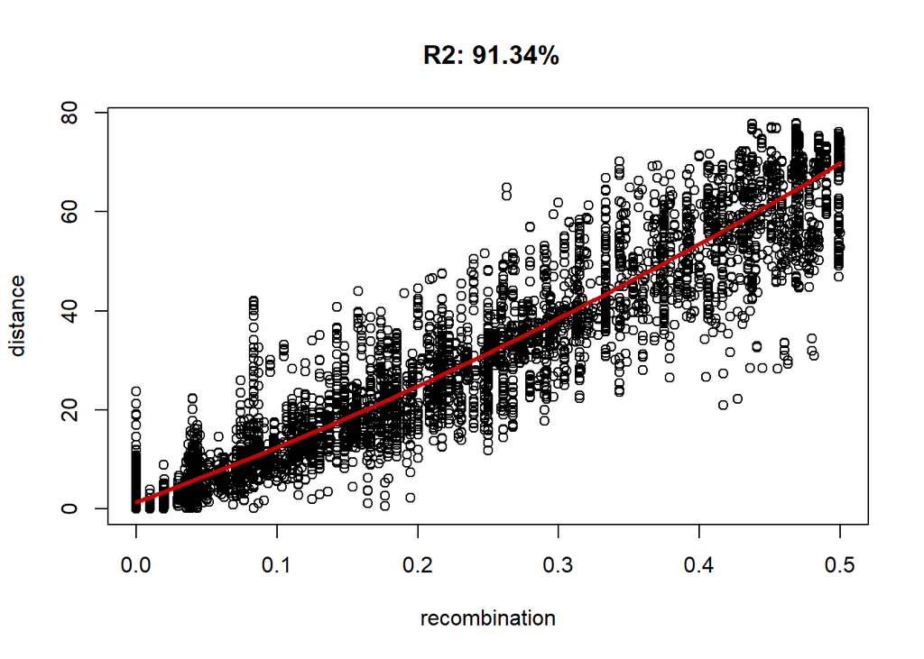

```r
#This indicates the relationship between recombination frequency and distance of the new map
recdist_plot(sm1$recdist)
```

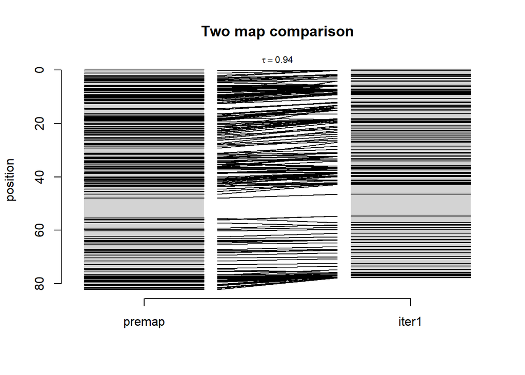

```r
#This compares the old and new maps obtained
#tau indicates order correlation between maps
iterplot(list(premap = sm1$oldmap,iter1 = sm1$newmap),
         main = "Two map comparison")
```

## Iterative smoothing

If you want to apply smooth descent iteratively and re-compute a linkage map each iteration, you can use `smooth_map_iter()` which does so automatically. To access the output the `extract()` function is quite useful.

```r
#We do not run this code to build the vignette faster
#results are equivalent to sd_iter object
sm5 <- smooth_map_iter(geno = geno, homologue = hom, iters = 5,
                    ploidy = 2, p1name = "P1", p2name = "P2",
                    mapping_ndim = 3, verbose = F)
```

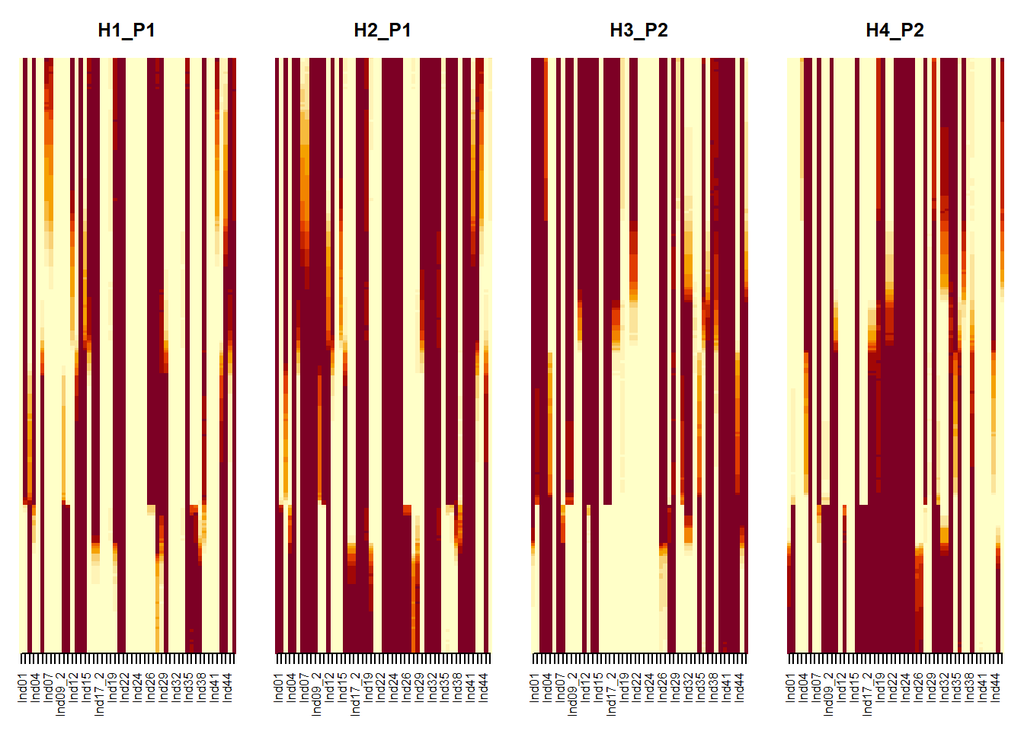

```r
#Use stored object for a faster vignette building
sm5 <- sd_iter

#The results of each iteration are equivalent to the output of smooth_map()
graphical_genotype(sm5$iter1$predIBD)
```

```r
#Use extract() to access results from all iterations
#To access the r2 of each iteration
r2 <- extract(sm5,"r2")
r2
```

```
##     iter1     iter2     iter3     iter4     iter5
## 0.9133763 0.9108866 0.9165587 0.9189696 0.9197175
```

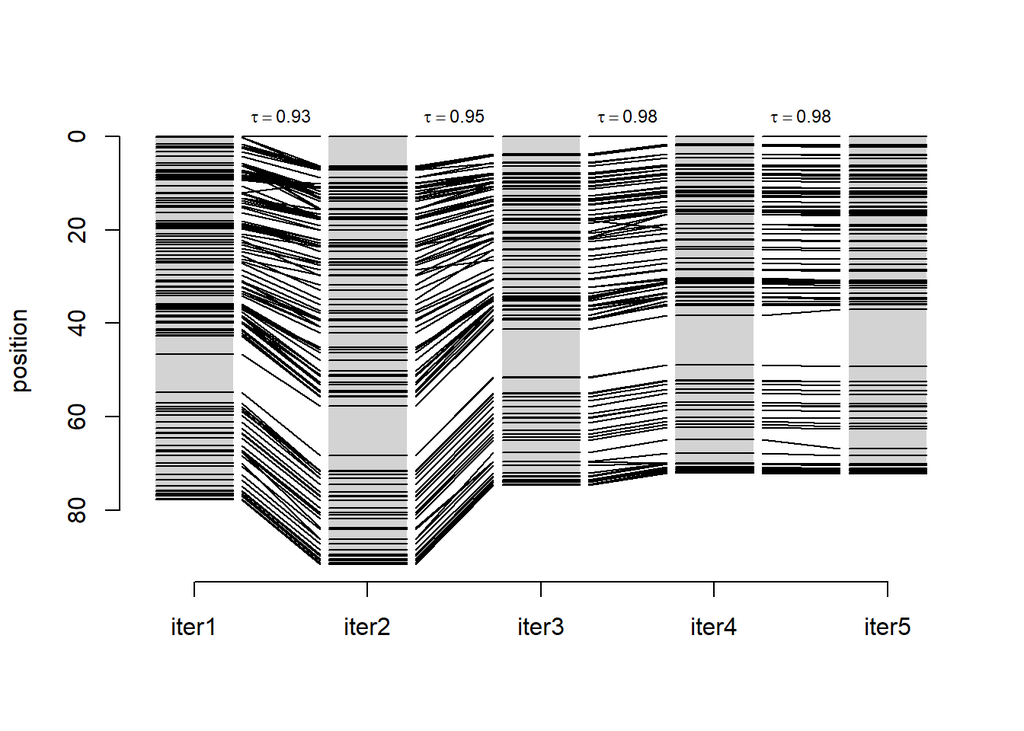

```r
#Or the newmaps of each iteration
newmaps <- extract(sm5,"newmap", simplify = F)
iterplot(newmaps)
```

# Introduction

In this vignette we’ll introduce the functions within the `SmoothDescent` package. We can divide them in three groups: basic functions, plotting functions and wrapper functions. Basic functions perform all the essential computations, but can be cumbersome to use if you just care about the output. Instead, wrapper functions use these basic functions and automate the analysis process. Plotting functions are diagnostic tools for analysing different types of output.

The R package `SmoothDescent` offers three wrapper functions that perform all computations:

- `smooth_descent()`: performs a signle run of the smooth descent algorithm without linkage mapping, but requires a marker map to be provided.
- `smooth_map()`: computes a linkage map, applies smooth descent and obtains a “corrected” linkage map.
- `smooth_map_iter()`: applies n iterations of the smooth descent algorithm. If n = 1 it is equivalent to `smooth_map()`.

In this section we’ll use the wrapper functions to understand the smooth descent algorithm, its inputs and its outputs.

So the inputs required for smooth descent are at least three: a population genotype matrix, a panretal homologue matrix (phased genotypes) and a marker order. There’s some example data in the package that we can have a look at:

```r
#A genotype matrix with column names and row names
knitr::kable(geno[1:15,1:15])
```

|  | P1 | P2 | Ind01 | Ind02 | Ind03 | Ind04 | Ind05 | Ind06 | Ind07 | Ind08 | Ind09 | Ind09_2 | Ind10 | Ind11 | Ind12 |
| --- | --- | --- | --- | --- | --- | --- | --- | --- | --- | --- | --- | --- | --- | --- | --- |
| m1 | 0 | 1 | 1 | 1 | 1 | 0 | 0 | 0 | 1 | 0 | 1 | 1 | 0 | 1 | 1 |
| m2 | 0 | 1 | 1 | 1 | 1 | 0 | 0 | 0 | 1 | 0 | 1 | 1 | 0 | 1 | 1 |
| m3 | 0 | 1 | 1 | 1 | 1 | 0 | 0 | 0 | 1 | 0 | 1 | 1 | 0 | 1 | 1 |
| m4 | 0 | 1 | 1 | 1 | 1 | 0 | 0 | 0 | 1 | 0 | 1 | 1 | 0 | 1 | 1 |
| m5 | 0 | 1 | 1 | 1 | 1 | 0 | 0 | 0 | 1 | 0 | 1 | 1 | 0 | 1 | 1 |
| m6 | 0 | 1 | 1 | 1 | 1 | 0 | 0 | 0 | 1 | 0 | 1 | 1 | 0 | 1 | 1 |
| m7 | 1 | 1 | 1 | 0 | 1 | 2 | 2 | 2 | 0 | 2 | 1 | 1 | 2 | 1 | 0 |
| m8 | 0 | 1 | 1 | 1 | 1 | 0 | 0 | 0 | 1 | 0 | 1 | 1 | 0 | 1 | 1 |
| m9 | 0 | 1 | 0 | 0 | 0 | 1 | 1 | 1 | 0 | 1 | 0 | 0 | 1 | 0 | 0 |
| m10 | 0 | 1 | 1 | 1 | 1 | 0 | 0 | 0 | 1 | 0 | 1 | 1 | 0 | 1 | 1 |
| m11 | 0 | 1 | 0 | 0 | 0 | 1 | 1 | 1 | 0 | 1 | 0 | 0 | 1 | 0 | 0 |
| m12 | 0 | 1 | 1 | 1 | 1 | 0 | 0 | 0 | 1 | 0 | 1 | 1 | 0 | 1 | 1 |
| m13 | 0 | 1 | 0 | 0 | 0 | 1 | 1 | 1 | 0 | 1 | 0 | 0 | 1 | 0 | 0 |
| m14 | 1 | 1 | 1 | 0 | 1 | 0 | 2 | 2 | 1 | 2 | 1 | 1 | 2 | 1 | 0 |
| m15 | 1 | 0 | 0 | 1 | 0 | 1 | 0 | 0 | 1 | 1 | 0 | 0 | 0 | 0 | 1 |

```r
#A homologue matrix with at least row names
knitr::kable(hom[1:15,])
```

|  | H1_P1 | H2_P1 | H3_P2 | H4_P2 |
| --- | --- | --- | --- | --- |
| m1 | 0 | 0 | 1 | 0 |
| m2 | 0 | 0 | 1 | 0 |
| m3 | 0 | 0 | 1 | 0 |
| m4 | 0 | 0 | 1 | 0 |
| m5 | 0 | 0 | 1 | 0 |
| m6 | 0 | 0 | 1 | 0 |
| m7 | 0 | 1 | 0 | 1 |
| m8 | 0 | 0 | 1 | 0 |
| m9 | 0 | 0 | 0 | 1 |
| m10 | 0 | 0 | 1 | 0 |
| m11 | 0 | 0 | 0 | 1 |
| m12 | 0 | 0 | 1 | 0 |
| m13 | 0 | 0 | 0 | 1 |
| m14 | 0 | 1 | 0 | 1 |
| m15 | 1 | 0 | 0 | 0 |

```r
#A map data.frame with at least two columns: marker and position
knitr::kable(map[1:15,])
```

| marker | position | physical |
| --- | --- | --- |
| m1 | 0.0000000 | 25171745 |
| m2 | 0.4756470 | 25434199 |
| m3 | 0.5966631 | 25429979 |
| m4 | 0.7218050 | 25239901 |
| m5 | 0.7787624 | 25315402 |
| m6 | 1.6409994 | 24829683 |
| m7 | 2.7461723 | 26840131 |
| m8 | 2.7752367 | 25200205 |
| m9 | 2.9472827 | 25048220 |
| m10 | 4.5729840 | 23668729 |
| m11 | 4.6679897 | 23400589 |
| m12 | 6.7881940 | 23930397 |
| m13 | 6.9590854 | 24848289 |
| m14 | 7.0419937 | 17723216 |
| m15 | 7.3721097 | 23859438 |

With this data we can already run the simplest wrapper, that just performs IBD calculation, error prediction and imputation of new IBDs. We also need to specify the `ploidy` (all even ploidies are accepted). The names of the parents (`p1name` and `p2name`) are assumed to be the two first columns in the genotype matrix, but it’s better to specify them.

```r
sd1 <- smooth_descent(geno,hom,map,
                      ploidy = 2, p1name = "P1", p2name = "P2")
```

```
## Obtaining IBD
## Predicting IBD
## Detecting errors
## Updating genotypes
## Counting recombinations
```

We can also obtain an improved map based on the newly estimated genotypes, and using our preliminary map as a starting order. The mapping is the slowest part of the process.

```r
#Result equivalent to sd_iter$iter1
sm1 <- smooth_map(geno,hom,map,
                  ploidy = 2, p1name = "P1", p2name = "P2")
```

If we want to run multiple iterations we can use `smooth_map_iter()`

```r
#Result equivalent to sd_iter
sm5 <- smooth_map_iter(geno,hom,map, iters = 5,
                       ploidy = 2, p1name = "P1", p2name = "P2",
                       verbose = F)
```

If we’re using `smooth_map()` or `smooth_map_iter()` the preliminary map is not necessary, and if not given it will be estimated at the beggining of the process. In both cases, the `mapping_ndim` parameter indicates the dimensions to use in `MDSmap` (2 or 3), 3 is more accurate but also quite slower. The `ncores` parameter can also be indicated, which uses parallelization for linkage estimation and speeds up the process.

## IBD outputs

```r
#Outputs of smooth descent
names(sd1)
```

```
## [1] "obsIBD"  "predIBD" "error"   "newIBD"  "oldgeno" "newgeno" "oldmap"
## [8] "rec"
```

All functions output a list with different items. The `obsIBD`, `predIBD`, `error` and `newIBD` are all lists of matrices, each with information about one homologue for all individuals:

- `obsIBD` contains observed IBD probabilities, based on random assortment of alleles. They are the basis of IBD prediction. NA values in this matrix mean that the observed genotype was impossible given the parental genotypes.
- `predIBD` contains predicted IBD probabilities, they are usually the most informative to see which parental chromosome has inherited each individual. NA values in this matrices indicate either that there was an impossible genotype in the observed IBDs, or that there was not enough information to predict IBDs (for example when there’s only markers from a single parent in a whole region).
- `error` contains a logical matrix, that indicates whether that marker is (TRUE) or not (FALSE) an error. Importantly, all missing values in the predIBD matrix are interpreted as errors.

```r
kable(sd1$obsIBD[[1]][1:15,1:10])
```

|  | Ind01 | Ind02 | Ind03 | Ind04 | Ind05 | Ind06 | Ind07 | Ind08 | Ind09 | Ind09_2 |
| --- | --- | --- | --- | --- | --- | --- | --- | --- | --- | --- |
| m1 | 0.5 | 0.5 | 0.5 | 0.5 | 0.5 | 0.5 | 0.5 | 0.5 | 0.5 | 0.5 |
| m2 | 0.5 | 0.5 | 0.5 | 0.5 | 0.5 | 0.5 | 0.5 | 0.5 | 0.5 | 0.5 |
| m3 | 0.5 | 0.5 | 0.5 | 0.5 | 0.5 | 0.5 | 0.5 | 0.5 | 0.5 | 0.5 |
| m4 | 0.5 | 0.5 | 0.5 | 0.5 | 0.5 | 0.5 | 0.5 | 0.5 | 0.5 | 0.5 |
| m5 | 0.5 | 0.5 | 0.5 | 0.5 | 0.5 | 0.5 | 0.5 | 0.5 | 0.5 | 0.5 |
| m6 | 0.5 | 0.5 | 0.5 | 0.5 | 0.5 | 0.5 | 0.5 | 0.5 | 0.5 | 0.5 |
| m7 | 0.5 | 1.0 | 0.5 | 0.0 | 0.0 | 0.0 | 1.0 | 0.0 | 0.5 | 0.5 |
| m8 | 0.5 | 0.5 | 0.5 | 0.5 | 0.5 | 0.5 | 0.5 | 0.5 | 0.5 | 0.5 |
| m9 | 0.5 | 0.5 | 0.5 | 0.5 | 0.5 | 0.5 | 0.5 | 0.5 | 0.5 | 0.5 |
| m10 | 0.5 | 0.5 | 0.5 | 0.5 | 0.5 | 0.5 | 0.5 | 0.5 | 0.5 | 0.5 |
| m11 | 0.5 | 0.5 | 0.5 | 0.5 | 0.5 | 0.5 | 0.5 | 0.5 | 0.5 | 0.5 |
| m12 | 0.5 | 0.5 | 0.5 | 0.5 | 0.5 | 0.5 | 0.5 | 0.5 | 0.5 | 0.5 |
| m13 | 0.5 | 0.5 | 0.5 | 0.5 | 0.5 | 0.5 | 0.5 | 0.5 | 0.5 | 0.5 |
| m14 | 0.5 | 1.0 | 0.5 | 1.0 | 0.0 | 0.0 | 0.5 | 0.0 | 0.5 | 0.5 |
| m15 | 0.0 | 1.0 | 0.0 | 1.0 | 0.0 | 0.0 | 1.0 | 1.0 | 0.0 | 0.0 |

```r
kable(sd1$predIBD[[1]][1:15,1:10],digits = 3)
```

|  | Ind01 | Ind02 | Ind03 | Ind04 | Ind05 | Ind06 | Ind07 | Ind08 | Ind09 | Ind09_2 |
| --- | --- | --- | --- | --- | --- | --- | --- | --- | --- | --- |
| m1 | 0 | 1 | 0 | 0.912 | 0 | 0 | 1.000 | 0.813 | 0 | 0 |
| m2 | 0 | 1 | 0 | 0.929 | 0 | 0 | 1.000 | 0.852 | 0 | 0 |
| m3 | 0 | 1 | 0 | 0.929 | 0 | 0 | 1.000 | 0.852 | 0 | 0 |
| m4 | 0 | 1 | 0 | 0.929 | 0 | 0 | 1.000 | 0.852 | 0 | 0 |
| m5 | 0 | 1 | 0 | 0.929 | 0 | 0 | 1.000 | 0.852 | 0 | 0 |
| m6 | 0 | 1 | 0 | 0.934 | 0 | 0 | 1.000 | 0.862 | 0 | 0 |
| m7 | 0 | 1 | 0 | 1.000 | 0 | 0 | 1.000 | 0.940 | 0 | 0 |
| m8 | 0 | 1 | 0 | 0.944 | 0 | 0 | 1.000 | 0.884 | 0 | 0 |
| m9 | 0 | 1 | 0 | 0.944 | 0 | 0 | 1.000 | 0.884 | 0 | 0 |
| m10 | 0 | 1 | 0 | 0.951 | 0 | 0 | 0.954 | 0.897 | 0 | 0 |
| m11 | 0 | 1 | 0 | 0.951 | 0 | 0 | 0.954 | 0.897 | 0 | 0 |
| m12 | 0 | 1 | 0 | 0.955 | 0 | 0 | 0.914 | 0.858 | 0 | 0 |
| m13 | 0 | 1 | 0 | 0.962 | 0 | 0 | 0.811 | 0.804 | 0 | 0 |
| m14 | 0 | 1 | 0 | 0.960 | 0 | 0 | 0.811 | 0.840 | 0 | 0 |
| m15 | 0 | 1 | 0 | 0.962 | 0 | 0 | 0.744 | 0.766 | 0 | 0 |

You might want to see the IBDs for a single individual. You can do that with the utility function `extract()`.

```r
predicted06 <- extract(sd1$predIBD,"Ind06")
kable(predicted06[1:15,])
```

|  | H1_P1 | H2_P1 | H3_P2 | H4_P2 |
| --- | --- | --- | --- | --- |
| m1 | 0 | 1 | 0 | 1 |
| m2 | 0 | 1 | 0 | 1 |
| m3 | 0 | 1 | 0 | 1 |
| m4 | 0 | 1 | 0 | 1 |
| m5 | 0 | 1 | 0 | 1 |
| m6 | 0 | 1 | 0 | 1 |
| m7 | 0 | 1 | 0 | 1 |
| m8 | 0 | 1 | 0 | 1 |
| m9 | 0 | 1 | 0 | 1 |
| m10 | 0 | 1 | 0 | 1 |
| m11 | 0 | 1 | 0 | 1 |
| m12 | 0 | 1 | 0 | 1 |
| m13 | 0 | 1 | 0 | 1 |
| m14 | 0 | 1 | 0 | 1 |
| m15 | 0 | 1 | 0 | 1 |

```r
#This individual inherited homologues 2 and 4
```

All the error matrices assign errors to the same positions, but for consistency four matrices are also returned.

```r
all(sd1$error[[1]] == sd1$error[[2]])
```

```
## [1] TRUE
```

Lastly, the newIBD matrices are used to impute new genotypes. In all cases we will get an `oldgeno` and `newgeno` list elements, which contain the corrected genotypes. We can see how many changes have been made.

```r
sum(sd1$oldgeno != sd1$newgeno)
```

```
## [1] 143
```

```r
mean(sd1$oldgeno != sd1$newgeno)
```

```
## [1] 0.01143268
```

In some cases, more errors are detected than can be confidently estimated. In the example dataset that is not the case.

```r
#Predicted errors
sum(sd1$error[[1]])
```

```
## [1] 143
```

```r
#Corrected errors
sum(sd1$oldgeno != sd1$newgeno)
```

```
## [1] 143
```

These outputs can be found not only from `smooth_descent()`, but also in the results from the mapping wrappers `smooth_map()` and `smooth_map_iter()`.

```r
names(sm1)
```

```
##  [1] "obsIBD"          "predIBD"         "error"           "newIBD"
##  [5] "oldgeno"         "newgeno"         "oldmap"          "rec"
##  [9] "newmap"          "eliminated"      "recdist"         "r2"
## [13] "tau"             "error_threshold"
```

```r
names(sm5$iter1)
```

```
##  [1] "obsIBD"          "predIBD"         "error"           "newIBD"
##  [5] "oldgeno"         "newgeno"         "oldmap"          "rec"
##  [9] "newmap"          "eliminated"      "recdist"         "r2"
## [13] "tau"             "error_threshold"
```